# rgee Workshop

Gopal Penny

10/25/2020

# `rgee` Workshop

The examples and most of the code below are from https://github.com/r-spatial/rgee.

To begin we’ll load `reticulate`, set our python environment, and load and initialize `rgee`.

```r
library(reticulate)
use_condaenv("r-reticulate")
library(rgee)

## It is necessary just once
# ee_install()

# Initialize Earth Engine!
ee_Initialize(email = "gopalpenny@gmail.com",drive=TRUE)
```

```
## ── rgee 1.0.5 ─────────────────────────────────────────────────────────────────────────────────────────────────────────────────────────── earthengine-api 0.1.235 ──
##  ✓ email: gopalpenny@gmail.com
##  ✓ Google Drive credentials:
 ✓ Google Drive credentials:  FOUND
##  ✓ Initializing Google Earth Engine:
 ✓ Initializing Google Earth Engine:  DONE!
##
 ✓ Earth Engine user: users/gopalpenny
## ────────────────────────────────────────────────────────────────────────────────────────────────────────────────────────────────────────────────────────────────────
```

```r
ee_check() # Check non-R dependencies
```

```
## ◉  Python version
## ✓ [Ok] /Users/gopal/.virtualenvs/rgee/bin/python v3.6
## ◉  Python packages:
## ✓ [Ok] numpy
## ✓ [Ok] earthengine-api
```

[output not shown]

## Example 1: Night time lights trend

```r
# Function to create an image band that stores time
createTimeBand <-function(img) {
  year <- ee$Date(img$get('system:time_start'))$get('year')$subtract(1991L)
  ee$Image(year)$byte()$addBands(img)
}

# Load Night time lights image collection
collection <- ee$
  ImageCollection('NOAA/DMSP-OLS/NIGHTTIME_LIGHTS')$
  select('stable_lights')$
  map(createTimeBand) # this map command adds the time band to each image within the collection
```

Now, calculate a linear trend in each pixel

```r
# Calculate the trend using a Reducer, which collapses multiple images to a single image
col_reduce <- collection$reduce(ee$Reducer$linearFit())
col_reduce <- col_reduce$addBands(
  col_reduce$select('scale')) # scale is the slope of the trend

# Print metadata for the resulting image
ee_print(col_reduce)
```

```
## ────────────────────────────────────────────────────────────────────────────────────────────────────────────────────────────────────────────── Earth Engine Image ──
## Image Metadata:
##  - Class                      : ee$Image
##  - ID                         : no_id
##  - Number of Bands            : 3
##  - Bands names                : scale offset scale_1
##  - Number of Properties       : 0
##  - Number of Pixels*          : 194400
##  - Approximate size*          : 607.50 KB
## Band Metadata (img_band = scale):
##  - EPSG (SRID)                : 4326
##  - proj4string                : +proj=longlat +datum=WGS84 +no_defs
##  - Geotransform               : 1 0 0 0 1 0
##  - Nominal scale (meters)     : 111319.5
##  - Dimensions                 : 360 180
##  - Number of Pixels           : 64800
##  - Data type                  : DOUBLE
##  - Approximate size           : 202.50 KB
##  ────────────────────────────────────────────────────────────────────────────────────────────────────────────────────────────────────────────────────────────────────
##  NOTE: (*) Properties calculated considering a constant geotransform and data type.
```

Map the trend

```r
# Map the temporal trend. Green -- no trend. Red band -- increase, Blue band - decrease
Map$setCenter(9.08203, 47.39835, 3)
Map$addLayer(
  eeObject = col_reduce,
  visParams = list(
    bands = c("scale", "offset", "scale"),
    min = 0,
    max = c(0.18, 20, -0.18)
  ),
  name = "stable lights trend"
)
```

## Example 2: Extract precipitation values

Load `tidyverse` for easy data wrangling and `sf` for spatial (i.e., vector) processing.

```r
library(tidyverse)
library(sf)
```

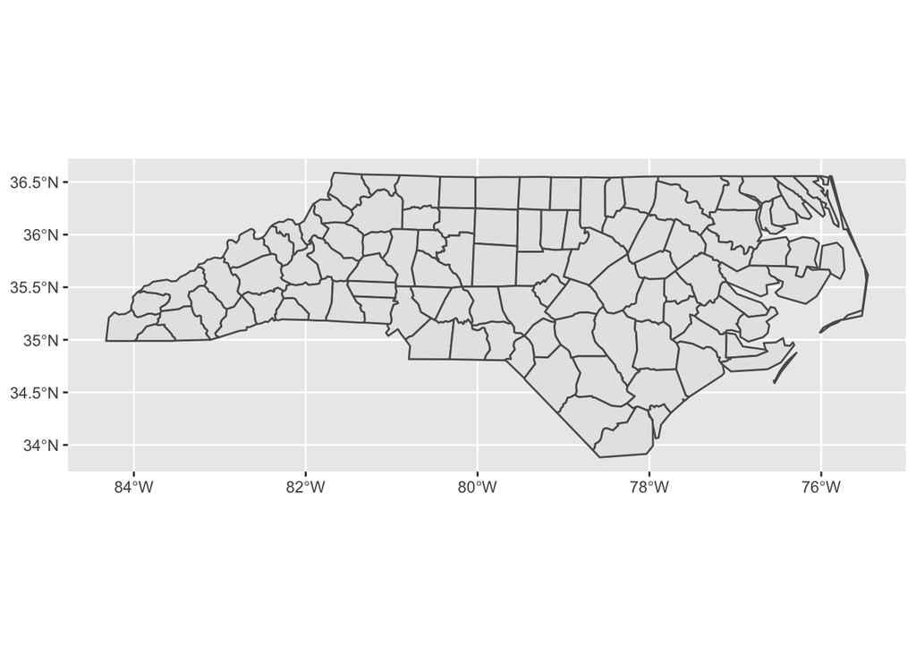

```r
nc <- st_read(system.file("shape/nc.shp", package = "sf"), quiet = TRUE)
# nc
ggplot() + geom_sf(data=nc,aes())
```

Define the image collection containing monthly precipitation values. Note that we filter the data to the year 2001.

```r
terraclimate <- ee$ImageCollection("IDAHO_EPSCOR/TERRACLIMATE")$
  filterDate("2001-01-01", "2002-01-01")$
  map(function(x) x$reproject("EPSG:4326")$select("pr"))
```

Extract and map precipitation values

```r
# Extract precip from earth engine
ee_nc_rain <- ee_extract(x = terraclimate, y = nc, sf = FALSE)
```

```
## Transforming current coordinates to EPSG:4326
```

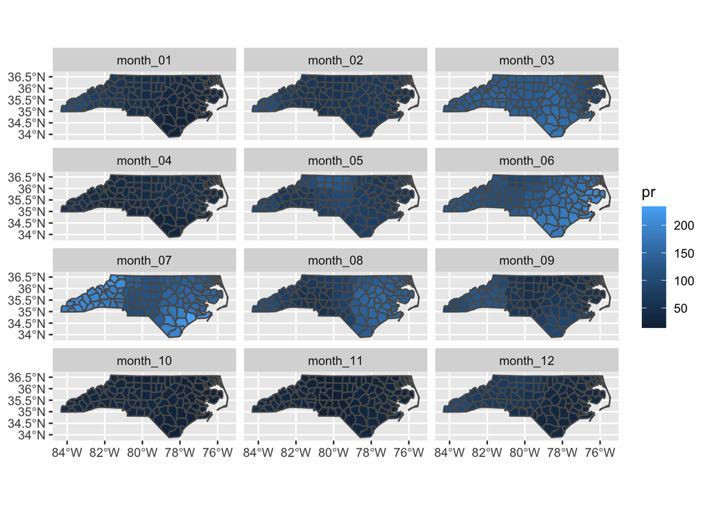

```r
colnames(ee_nc_rain) <- paste0("month_",sprintf("%02d", 1:12))
nc_rain <- nc %>% bind_cols(ee_nc_rain)

# Convert vector to "long" format -- i.e., 1 row per county-month combination
nc_rain_long <- nc_rain %>% gather("month","pr",starts_with("month_"))

# Use ggplot with geom_sf for spatial maps, and use facet_wrap to include a panel for each month
ggplot() + geom_sf(data=nc_rain_long,aes(fill=pr)) + facet_wrap(~month,ncol = 3)
```

Plot the same data as a timeseries

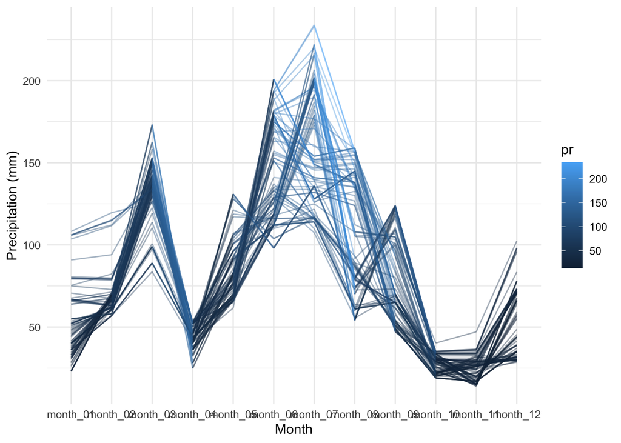

```r
ggplot(nc_rain_long, aes(x = month, y = pr, group = NAME, color = pr)) +
  geom_line(alpha = 0.4) +
  xlab("Month") +
  ylab("Precipitation (mm)") +
  theme_minimal()
```

## Example 3: Create an NDVI-animation

Javascript version: https://developers.google.com/earth-engine/tutorials/community/modis-ndvi-time-series-animation

```r
# Define the regional bounds of animation frames and a mask to clip the NDVI data by.
mask <- system.file("shp/arequipa.shp", package = "rgee") %>%
  st_read(quiet = TRUE) %>%
  sf_as_ee()
region <- mask$geometry()$bounds()

# Retrieve the MODIS Terra Vegetation Indices 16-Day Global 1km dataset as an ee.ImageCollection and select the NDVI band.
col <- ee$ImageCollection('MODIS/006/MOD13A2')$select('NDVI')

ee_print(mask)
```

```
## ────────────────────────────────────────────────────────────────────────────────────────────────────────────────────────────────── Earth Engine FeatureCollection ──
## FeatureCollection Metadata:
##  - Class                      : ee$FeatureCollection
##  - Number of Features         : 1
##  - Number of Properties       : 0
## Feature Metadata:
##  - Number of Properties       : 2
## Geometry Metadata (f_index = 0):
##  - EPSG (SRID)                : 4326
##  - proj4string                : +proj=longlat +datum=WGS84 +no_defs
##  - Geotransform               : 1 0 0 0 1 0
##  - Geodesic                   : TRUE
##  - WKT                        : POLYGON
##  ────────────────────────────────────────────────────────────────────────────────────────────────────────────────────────────────────────────────────────────────────
```

```r
# Group images by composite date
col <- col$map(function(img) {
  doy <- ee$Date(img$get('system:time_start'))$getRelative('day', 'year')
  img$set('doy', doy)
})
distinctDOY <- col$filterDate('2013-01-01', '2014-01-01')
```

```r
filter <- ee$Filter$equals(leftField = 'doy', rightField = 'doy');

# Define a join; convert the resulting FeatureCollection to an ImageCollection.

join <- ee$Join$saveAll('doy_matches')
joinCol <- ee$ImageCollection(join$apply(distinctDOY, col, filter))

comp <- joinCol$map(function(img) {
  doyCol = ee$ImageCollection$fromImages(
    img$get('doy_matches')
  )
  doyCol$reduce(ee$Reducer$median())
})
```

```r
# Create the visualization
visParams = list(
  min = 0.0,
  max = 9000.0,
  bands = "NDVI_median",
  palette = c(
    'FFFFFF', 'CE7E45', 'DF923D', 'F1B555', 'FCD163', '99B718', '74A901',
    '66A000', '529400', '3E8601', '207401', '056201', '004C00', '023B01',
    '012E01', '011D01', '011301'
    )
)

rgbVis <- comp$map(function(img) {
  do.call(img$visualize, visParams) %>%
    ee$Image$clip(mask)
})
```

```r
# Create the GIF
gifParams <- list(
  region = region,
  dimensions = 600,
  crs = 'EPSG:3857',
  framesPerSecond = 10
)


print(rgbVis$getVideoThumbURL(gifParams))
```

```
## [1] "https://earthengine.googleapis.com/v1alpha/projects/earthengine-legacy/videoThumbnails/d77a77ab0638bf42a3539de910705169-602d7d18dbe551ffdd2184179edf96d3:getPixels"
```

The GIF image is located at the URL given above. The following command automatically navigates your web browser to this URL.

```r
browseURL(rgbVis$getVideoThumbURL(gifParams))
```

## Final thoughts

The `rgee` package is fantastic for simple data retrieval. In my experience, it has a few drawbacks compared with the native GEE javascript portal:

- Less interactive – for example, GEE portal allows you to query raster pixels in the map.
- `rgee` commands hold your R session hostage – GEE doesn’t process in the background
- Difficulties interrupting GEE – may have to force quit R / RStudio